# Text Wrangling

Vicki Hertzberg

2/8/2023

## Working with Text

Machines ==> Good at storing text, not so good at understanding text

Humans ==> Good at understanding text, not so good at storing text

To process text, you need an extra set of wrangling skills. We are now going to introduce how to - *ingest* text - create *corpora* (collections of text document) - use *regular expressions* to automate text searches

First let’s call up the packages we will need:

```r
library(RCurl); packageVersion("RCurl")
```

```
## [1] '1.98.1.9'
```

```r
library(tidyverse); packageVersion("tidyverse")
```

```
## [1] '1.3.2'
```

```r
library(stringr); packageVersion("stringr")
```

```
## [1] '1.5.0'
```

```r
library(rvest); packageVersion("rvest")
```

```
## [1] '1.0.3'
```

```r
library(methods); packageVersion("methods")
```

```
## [1] '4.0.3'
```

```r
library(tm); packageVersion("tm")
```

```
## [1] '0.7.10'
```

```r
library(wordcloud); packageVersion("wordcloud")
```

```
## [1] '2.6'
```

```r
library(RColorBrewer); packageVersion("RColorBrewer")
```

```
## [1] '1.1.3'
```

```r
library(janitor); packageVersion("janitor")
```

```
## [1] '2.1.0'
```

```r
library(tidytext); packageVersion("tidytext")
```

```
## [1] '0.4.1'
```

We are going to use text mining techniques to explore the play *The Tragedy of Hamlet, Prince of Denmark*, aka *Hamlet*. To do this, we are going to pull the text from the Project Gutenberg site, (http://www.gutenberg.org)[http://www.gutenberg.org]. Project Gutenberg has over 53,000 electronic books and other text documents that you can download *for free*.

```r
# Get the text of Hamlet

# We have called the package RCurl previously to allow us to call the URL
hamlet_url <- "http://www.gutenberg.org/cache/epub/1787/pg1787.txt"
Hamlet_raw0 <- read_html(hamlet_url)
Hamlet_raw0 %>%
  html_nodes("p") %>%
  html_text() -> Hamlet_raw
```

Note that the object `Hamlet_raw` is a *single string* of text containing the entire play.

To work with this, we are going to have to split this string into a vector of strings, and we will do this using the function `strsplit()`. We will also have to specify the end of line character(s), which in this case are: `\r\n`.

```r
# split string at end of line codes (\r\n); this returns a list - we only want the first element in the list
hamlet <- strsplit(Hamlet_raw, "\r\n")[[1]]
length(hamlet)
```

```
## [1] 5079
```

Now let’s examine the text:

```r
#examine the text - list out some elements
hamlet[350:360]
```

```
##  [1] "    When he th' ambitious Norway combated."
##  [2] "    So frown'd he once when, in an angry parle,"
##  [3] "    He smote the sledded Polacks on the ice."
##  [4] "    'Tis strange."
##  [5] "  Mar. Thus twice before, and jump at this dead hour,"
##  [6] "    With martial stalk hath he gone by our watch."
##  [7] "  Hor. In what particular thought to work I know not;"
##  [8] "    But, in the gross and scope of my opinion,"
##  [9] "    This bodes some strange eruption to our state."
## [10] "  Mar. Good now, sit down, and tell me he that knows,"
## [11] "    Why this same strict and most observant watch"
```

Notice that in this new `hamlet` object there are two spaces between the start of a line, then an abbreviation for the speaker’s name, then another space. We can take advantage of this and other patterns to quantify the ideas within the text. As an example, let’s see how many times Hamlet speaks.

```r
# get the number of lines that Hamlet speaks
hamlet_lines <- grep("  Ham. ", hamlet, value = TRUE)
length(hamlet_lines)
```

```
## [1] 358
```

```r
# inspect the data
head(hamlet_lines)
```

```
## [1] "  Ham. [aside] A little more than kin, and less than kind!"
## [2] "  Ham. Not so, my lord. I am too much i' th' sun."
## [3] "  Ham. Ay, madam, it is common."
## [4] "  Ham. Seems, madam, Nay, it is. I know not 'seems.'"
## [5] "  Ham. I shall in all my best obey you, madam."
## [6] "  Ham. O that this too too solid flesh would melt,"
```

Look at the difference if we don’t consider the space after the abbreviation in our expression to evaluate:

```r
# get the number of lines that Hamlet speaks
hamlet_lines <- grep("  Ham.", hamlet, value = TRUE)
length(hamlet_lines)
```

```
## [1] 364
```

```r
# inspect the data
head(hamlet_lines)
```

```
## [1] "  Hamlet, son to the former, and nephew to the present king."
## [2] "  Ham. [aside] A little more than kin, and less than kind!"
## [3] "  Ham. Not so, my lord. I am too much i' th' sun."
## [4] "  Ham. Ay, madam, it is common."
## [5] "  Ham. Seems, madam, Nay, it is. I know not 'seems.'"
## [6] "  Ham. I shall in all my best obey you, madam."
```

We will see that happens down below.

The `grep()` function is what you use when you want to use R to find a needle in a haystack. The first argument to the function is a *regular expression* (i.e., a pattern) that you want to find, and the second argument is the character vector in which you want to find the patterns. Note that if you do not include “value = TRUE”, the function will return the indices of the haystack in which the needles were found. To illustrate, let’s look for Ophelia’s lines;

```r
# find Ophelia's lines
ophelia_lines <- grep(" Oph. ", hamlet)
length(ophelia_lines)
```

```
## [1] 58
```

```r
head(ophelia_lines)
```

```
## [1] 782 789 825 870 874 884
```

The function `grepl()` uses the same syntax but returns instead a logical vector as long as the haystack. For example,

```r
#illustrate differences between grep and grepl
length(grep("  Ham. ", hamlet))
```

```
## [1] 358
```

```r
length(grepl("  Ham. ", hamlet))
```

```
## [1] 5079
```

To extract the piece of each matching line that actually matched, use the `str_extract()` function from the `stringr` package.

```r
# Extract the lines that match
# To do this you need to have called up the package stringr
pattern <- "  Ham. "
grep(pattern, hamlet, value = TRUE) %>%
  str_extract(pattern) %>%
  head()
```

```
## [1] "  Ham. " "  Ham. " "  Ham. " "  Ham. " "  Ham. " "  Ham. "
```

*Regular expressions* are very powerful and very commonly used in many different environments. Understanding the concept of regular expressions will pay off in the long term.

# Regular Expression Syntax

- *.* is a metacharacter that matches any character. If you want to search for the literal values of a metacharacter, you have to use two backslashes in R.

```r
# Example of use of . as a metacharacter

hamlet_lines <- grep("  Ham.", hamlet, value = TRUE)
length(hamlet_lines)
```

```
## [1] 364
```

```r
hamlet_lines <- grep("  Ham. ", hamlet, value = TRUE)
length(hamlet_lines)
```

```
## [1] 358
```

```r
hamlet_lines <- grep("  Ham\\.", hamlet, value = TRUE)
length(hamlet_lines)
```

```
## [1] 358
```

- *Character sets:* Use brackets to define sets of characters to match.

```r
# Example os use of character sets

head(grep("H[b-z]", hamlet, value = TRUE))
```

```
## [1] "**Etexts Readable By Both Humans and By Computers, Since 1971**"
## [2] "*These Etexts Prepared By Hundreds of Volunteers and Donations*"
## [3] "  Horatio, friend to Hamlet."
## [4] "  Ber. He."
## [5] "    If you do meet Horatio and Marcellus,"
## [6] "                    Enter Horatio and Marcellus."
```

This notation will result in each occurrence of H followed by any small letter except “a”.

- *Alternation:* For this we use the symbol `|` within parentheses.

```r
# Example of alternation

head(grep("  H(a|o)", hamlet, value = TRUE))
```

```
## [1] "  Hamlet, son to the former, and nephew to the present king."
## [2] "  Horatio, friend to Hamlet."
## [3] "  Hor. Friends to this ground."
## [4] "  Hor. A piece of him."
## [5] "  Hor. Tush, tush, 'twill not appear."
## [6] "  Hor. Well, sit we down,"
```

So you see that using the `H(a|o)` alternation allows us to pick up any lines in which occurs the sequence ” Ha” or ” Ho”.

- *Anchors:* Use `^` to anchor a pattern to the beginning of a text, and use `$` to anchor it to the end.

```r
# Example of anchor at the beginning
head(grep("^  H[b-z]", hamlet, value = TRUE))
```

```
## [1] "  Horatio, friend to Hamlet."
## [2] "  Hor. Friends to this ground."
## [3] "  Hor. A piece of him."
## [4] "  Hor. Tush, tush, 'twill not appear."
## [5] "  Hor. Well, sit we down,"
## [6] "  Hor. Most like. It harrows me with fear and wonder."
```

- *Repetitions:* Specify the number of times that we want a certain pattern to occur.
  - `?` means zero or one time
  - `*` means zero or more times
  - `+` means one or more times

```r
# Examples of repetitive patterns

head(grep("  $H(a|o)", hamlet, value = TRUE))
```

```
## character(0)
```

```r
# Examples of repetitive patterns

head(grep("  *H(a|o)", hamlet, value = TRUE))
```

```
## [1] "This etext is a typo-corrected version of Shakespeare's Hamlet,"
## [2] "The Tragedy of Hamlet, Prince of Denmark"
## [3] "        Mail:  Prof. Michael Hart"
## [4] "  Hamlet, son to the former, and nephew to the present king."
## [5] "  Horatio, friend to Hamlet."
## [6] "  Gertrude, Queen of Denmark, mother to Hamlet."
```

```r
# Examples of repetitive patterns

head(grep("  +H(a|o)", hamlet, value = TRUE))
```

```
## [1] "  Hamlet, son to the former, and nephew to the present king."
## [2] "  Horatio, friend to Hamlet."
## [3] "  Hor. Friends to this ground."
## [4] "  Hor. A piece of him."
## [5] "  Hor. Tush, tush, 'twill not appear."
## [6] "  Hor. Well, sit we down,"
```

So how do we use these techniques to analyze the text?

- What can we learn by noting who speaks when? _ When does each character speak as a function of the line number in the play?

```r
# Assign the characters
Hamlet <- grepl("  Ham\\.", hamlet)
Ophelia <- grepl("  Oph\\.", hamlet)
Polonius <- grepl("  Pol\\.", hamlet)
Gertrude <- grepl("  Queen\\.", hamlet)
Laertes <- grepl("  Laer\\.", hamlet)
Claudius <- grepl("  King\\.", hamlet)
Horatio <- grepl("  Hor\\.", hamlet)
Fortinbras <- grepl("  For\\.", hamlet)

length(Hamlet)
```

```
## [1] 5079
```

```r
length(Ophelia)
```

```
## [1] 5079
```

```r
length(Polonius)
```

```
## [1] 5079
```

```r
length(Gertrude)
```

```
## [1] 5079
```

```r
length(Laertes)
```

```
## [1] 5079
```

```r
length(Claudius)
```

```
## [1] 5079
```

```r
length(Horatio)
```

```
## [1] 5079
```

```r
length(Fortinbras)
```

```
## [1] 5079
```

```r
sum(Hamlet)
```

```
## [1] 358
```

```r
sum(Ophelia)
```

```
## [1] 58
```

```r
sum(Polonius)
```

```
## [1] 86
```

```r
sum(Gertrude)
```

```
## [1] 74
```

```r
sum(Laertes)
```

```
## [1] 62
```

```r
sum(Claudius)
```

```
## [1] 106
```

```r
sum(Horatio)
```

```
## [1] 108
```

```r
sum(Fortinbras)
```

```
## [1] 2
```

```r
speaker_freq <- data.frame(Hamlet, Polonius, Claudius, Horatio, Ophelia, Gertrude, Laertes) %>%
  mutate(line=1:length(hamlet)) %>%
  gather(key = "character", value = "speak", -line) %>%
  mutate(speak = as.numeric(speak)) %>%
  filter(line > 273 & line < 5131)
```

Another thing to do before we do the deep dive: Let’s create some context of helpful information, namely the lines at which each Act starts and stops.

```r
# Delineate the Acts
acts_idx <- grep("^A[C|c][T|t] [I|V]+", hamlet)
acts_labels <- str_extract(hamlet[acts_idx], "^A[C|c][T|t] [I|V]+")
acts <- data.frame(line=acts_idx, labels = acts_labels)
```

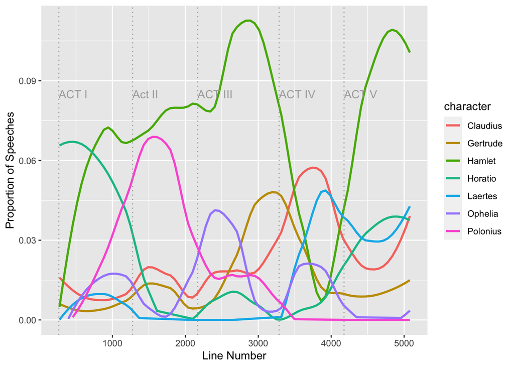

```r
# Plot the lines at which each character speaks
ggplot(data = speaker_freq, aes(x=line, y=speak)) +
  geom_smooth(aes(color=character), method = "loess", se = 0, span = 0.4) +
  geom_vline(xintercept = acts_idx, color = "darkgray", lty = 3) +
  geom_text(data = acts, aes(y=0.085, label = labels), hjust = "left", color = "darkgray") +
  ylim(c(0, NA)) +
  xlab("Line Number") +
  ylab("Proportion of Speeches")
```

We can also ingest text by scraping it from the internet. Let’s look at the discography of David Bowie, as listed on Wikipedia:

Get the data

```r
url <- "https://en.wikipedia.org/wiki/List_of_songs_recorded_by_David_Bowie"
tables <- url %>%
  read_html() %>%
  html_nodes("table")
Bowie_songs <- tables %>%
  purrr::pluck(3) %>%
  html_table(fill = TRUE) %>%
  janitor::clean_names() %>%
  select(song, writer_s, year)
glimpse(Bowie_songs)
```

```
## Rows: 415
## Columns: 3
## $ song     <chr> "\"1917\"", "\"1984\"", "\"5:15 The Angels Have Gone\"", "\"'…
## $ writer_s <chr> "David BowieReeves Gabrels", "David Bowie", "David Bowie", "D…
## $ year     <chr> "1999", "1974", "2002", "1987", "1991", "1986", "1975", "2002…
```

First let’s clean this up a bit more.

```r
# Clean the data

Bowie_songs <- Bowie_songs %>%
  mutate(song = gsub('\\"', "", song), year = as.numeric(year))
glimpse(Bowie_songs)
```

```
## Rows: 415
## Columns: 3
## $ song     <chr> "1917", "1984", "5:15 The Angels Have Gone", "'87 and Cry", "…
## $ writer_s <chr> "David BowieReeves Gabrels", "David Bowie", "David Bowie", "D…
## $ year     <dbl> 1999, 1974, 2002, 1987, 1991, 1986, 1975, 2002, 1979, 1970, 1…
```

It appears that Bowie recorded 400 songs. Who wrote all of them?

```r
# Count the number of different songwriters
pattern <- "Bowie"
Bowie_songs$bowie_wrote <- grepl(pattern, Bowie_songs$writer_s)
sum(Bowie_songs$bowie_wrote)
```

```
## [1] 348
```

Such a prolific writer, what was he writing about?

```r
Bowie_songs %>% filter(bowie_wrote == "TRUE") -> Bowie_songs_only
```

So what did Bowie write about?

```r
Bowie_songs_only %>%
  unnest_tokens(word, song) %>%
  anti_join(get_stopwords(), by = "word") %>%
  count(word, sort = TRUE) %>%
  arrange(desc(n))  -> Bowie_words
```

```r
#Get rid of parentheses and words in between
Bowie_songs_only$song <- gsub(" *\\(.*?\\) *","",as.character(Bowie_songs_only$song))

# Get rid of square brackets and words in between (used by Wikipedia to denote footnotes)
Bowie_songs_only$song <- gsub(" *\\[.*?\\] *","",as.character(Bowie_songs_only$song))

# Get rid of leading and trailing whitespace
Bowie_songs_only$song <- trimws(Bowie_songs_only$song, "both")

Bowie_songs_only %>%
  select(song) %>%
  unnest_tokens(word, song) %>%
  anti_join(get_stopwords(), by = "word") %>%
  count(word, sort = TRUE) %>%
  arrange(desc(n)) -> Bowie_words
```

Another way to look at text is to create a *word cloud*, which you can think of as a multivariate histogram for words. You will be surprised, I’m sure, to learn that R has a `wordcloud` package that will allow you to create this object.

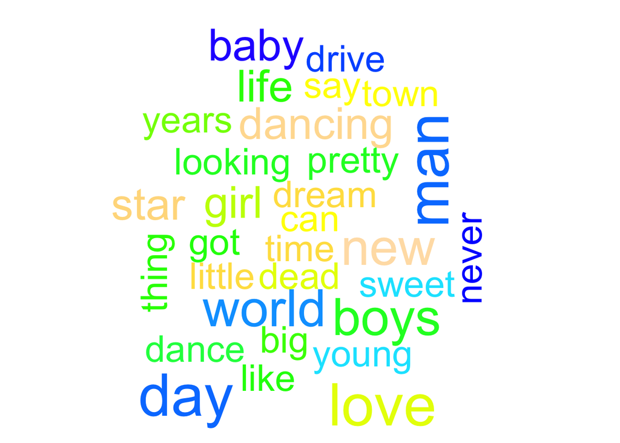

```r
# Create wordcloud from Bowie song titles

#We need to have the package wordcloud and RColorBrewer for this to work.
wordcloud(words = Bowie_words$word, freq = Bowie_words$n, max.words = 30, scale = c(4, 1), colors = topo.colors(n=30), random.color = TRUE)
```